# Tarea 1

Aslie Cárdenas Sandoval

2024-08-08

### Ejercicio 1

##### a) Diferencias entre: Estadística, Análisis de Datos, Minería de Datos, “Machine Learning”, “Big Data” y Ciencia de Datos.

Basado en la conferencia “Desde la Estadística hasta la Ciencia de Datos Pasando por el concepto de Big Data”:

- Estadística: La estadística es la ciencia que utiliza conjuntos de datos (muestras) numéricos para obtener deducciones basadas en el cálculo de probabilidades.
- Minería de Datos: La minería de datos se basa en la extracción de información de grandes bases de datos utilizando medios automatizados con el fin de encontrar patrones en los datos. A diferencia de la estadística, que usa muestras, la minería de datos utiliza toda la base de datos.
- Machine Learning: El machine learning es muy parecido a la minería de datos, pero tienen enfoques diferentes. Mientras que la minería de datos utiliza métodos automatizados para encontrar patrones y tomar decisiones, el machine learning se centra en escribir algoritmos que puedan aprender de los datos y mejorar con el tiempo.
- Big Data: Big data se refiere a conjuntos de datos muy grandes que tienen tres características principales: volumen, variedad y velocidad. Estas características permiten procesar y analizar datos en tiempo real.
- Análisis de Datos: El análisis de datos implica recopilar, limpiar y transformar los datos con el objetivo de descubrir información útil, llegar a conclusiones y apoyar la toma de decisiones. Utiliza herramientas para encontrar patrones y hacer pronósticos.
- Ciencia de Datos: La ciencia de datos es una disciplina más amplia que combina varios campos, como la estadística, minería de datos, machine learning, analítica predictiva y programación, para extraer datos relevantes y obtener conocimientos útiles.

##### b) Relación entre la evolución de la capacidad de almacenamiento y explosión en la cantidad de datos.

- La evolución de la capacidad de almacenamiento ha sido fundamental para manejar la explosión de datos. A medida que la capacidad de almacenamiento ha aumentado desde tarjetas perforadas hasta disquetes, discos duros, memorias USB, y ahora nanotecnología ha sido posible almacenar y procesar volúmenes de datos cada vez mayores. Esta expansión en la capacidad ha facilitado la generación y acumulación exponencial de datos, impulsada por redes sociales, dispositivos móviles, Internet y sensores. Sin estos avances en almacenamiento, no se podría manejar la enorme cantidad de datos que se produce y se utiliza actualmente en diversos campos.

### Ejercicio 2

- “x” y “y” como vectores

```r
x <- c(3, -5, 31, -1, -9, 10, 0, 18)
y <- c(1, 1, -3, 1, -99, -10, 10, -7)
```

- Media, la varianza, la raíz cuadrada y la desviaciÓn estándar de y.

```r
media.y<-mean(y)
varianza.y<-var(y)
desviacion.y<-sd(y)
raiz.cuadrada.y<-sqrt(y)
cat("Media y:", media.y)
```

```
## Media y: -13.25
```

```r
cat("Varianza y:", varianza.y)
```

```
## Varianza y: 1236.786
```

```r
cat("Raíz cuadrada y:", raiz.cuadrada.y)
```

```
## Raíz cuadrada y: 1 1 NaN 1 NaN NaN 3.162278 NaN
```

```r
cat("Desviacion estandar y:", desviacion.y,"\n")
```

```
## Desviacion estandar y: 35.16796
```

```r
media.x<-mean(x)
varianza.x<-var(x)
desviacion.x<-sd(x)
raiz.cuadrada.x<-sqrt(x)
cat("Media x:", media.y)
```

[output not shown]

```r
cat("Varianza x:", varianza.y)
```

[output not shown]

```r
cat("Raíz cuadrada x:", raiz.cuadrada.y)
```

[output not shown]

```r
cat("Desviacion estandar x:", desviacion.y,"\n")
```

[output not shown]

- Correlación entre x y y.

```r
correlacion_xy <- cor(x, y)
cat("Correlación xy:", correlacion_xy)
```

```
## Correlación xy: 0.3659679
```

- Comando en R para extraer las entradas 2 a la 7 de x.

```r
entradas.2.a.7<-x[2:7]
print(entradas.2.a.7)
```

```
## [1] -5 31 -1 -9 10  0
```

- Comando en R para extraer las entradas de y excepto la 2 y la 7.

```r
sin.entradas<-y[-c(2,7)]
print(sin.entradas)
```

```
## [1]   1  -3   1 -99 -10  -7
```

- Comando en R para extraer las entradas de y menores a -3 o mayores a 10.

```r
menor.mayor.y <- y[y < -3 | y > 10]
print(menor.mayor.y)
```

```
## [1] -99 -10  -7
```

- Comando en R para extraer las entradas de x mayores a 0 y que sean números pares.

```r
mayor.par.x <- x[x > 0 & x%%2 == 0]
print(mayor.par.x)
```

```
## [1] 10 18
```

### Ejercicio 3

```r
A <-matrix(data =c(1,2,3,4,5,6,7,8,9,10,11,12), nrow = 4, byrow = T)
A
```

```
##      [,1] [,2] [,3]
## [1,]    1    2    3
## [2,]    4    5    6
## [3,]    7    8    9
## [4,]   10   11   12
```

```r
cat('Datos primera fila, columna del 1 al 3:', A[1, 1:3], '\n')
```

```
## Datos primera fila, columna del 1 al 3: 1 2 3
```

```r
cat('Todas las filas de la segunda columna):', A[1:4, 2], '\n')
```

```
## Todas las filas de la segunda columna): 2 5 8 11
```

```r
cat('Elemento en fila 3, columna 3:', A[3, 3], '\n')
```

```
## Elemento en fila 3, columna 3: 9
```

```r
cat('Elemento 11 en orden de columnas:', A[11], '\n')
```

```
## Elemento 11 en orden de columnas: 9
```

```r
cat('No existe elemento 20 para acceder', "A[20]", '\n')
```

```
## No existe elemento 20 para acceder A[20]
```

```r
cat('Fila 5, columna 4, no existe', "A[5, 4]", '\n')
```

```
## Fila 5, columna 4, no existe A[5, 4]
```

```r
cat('No hay tercera dimesion para acceder', "A[1, 1, 1]", '\n')
```

```
## No hay tercera dimesion para acceder A[1, 1, 1]
```

### Ejercicio 4

- Para qué sirven los comandos de R as.matrix(…) y as.data.frame(…), explique y dé un ejemplo de cada uno.
- as.matrix(): Se utiliza para convertir objetos en matrices. Por ejemplo, convertir un dataframe a matriz

```r
df <- data.frame(A = 1:4, B = 5:8, C = 9:12)

matriz <- as.matrix(df)

print(matriz)
```

```
##      A B  C
## [1,] 1 5  9
## [2,] 2 6 10
## [3,] 3 7 11
## [4,] 4 8 12
```

- as.data.frame(): Se utiliza para convertir objetos en un data frame. Por ejemplo, convertir una lista a un dataframe

```r
lista <- list(Nombres = c("Alice", "Bob", "Charlie"),
              Edades = c(25, 30, 35),
              Ciudad = c("New York", "Los Angeles", "Chicago"))

data_frame <- as.data.frame(lista)

print(data_frame)
```

```
##   Nombres Edades      Ciudad
## 1   Alice     25    New York
## 2     Bob     30 Los Angeles
## 3 Charlie     35     Chicago
```

### Ejercicio 5

```r
df2 <- data.frame(Peso = c(76, 67, 55, 57, 87, 48),
                  Edad = c(25, 23, 19, 18, 57, 13),
                  Nivel_Educativo = c("Lic", "Bach", "Bach", "Bach", "Dr", "MSc"))
print(df2)
```

```
##   Peso Edad Nivel_Educativo
## 1   76   25             Lic
## 2   67   23            Bach
## 3   55   19            Bach
## 4   57   18            Bach
## 5   87   57              Dr
## 6   48   13             MSc
```

### Ejercicio 6

```r
x <- c(2, -5, 4, 6, -2, 8)
```

- y = (2, 4, 6, 8). Vector formado por las componentes positivas de x.

```r
y <- x[x > 0]
print(y)
```

```
## [1] 2 4 6 8
```

- z = (−5, −2). Vector formado por las componentes negativas de x.

```r
z <- x[x < 0]
print(z)
```

```
## [1] -5 -2
```

- v = (−5, 4, 6, −2, 8). Vector x eliminada la primera componente.

```r
v <- x[-c(1)]
print(v)
```

```
## [1] -5  4  6 -2  8
```

- w = (2, 4, −2). Vector x tomando las componentes con ´ındice impares, es decir, x[1] = 2, x[3] = 4 y x[5] = −2.

```r
w <- x[seq(1, length(x), by = 2)]
print(w)
```

```
## [1]  2  4 -2
```

### Ejercicio 7

- Queremos representar gráficamente la función coseno en el intervalo [0, 2π]. Para esto creamos el vector x de la siguiente forma x<-seq(0,2*pi,length=100). ¿Cuál es la diferencia entre las gráficas obtenidas por comandos plot?

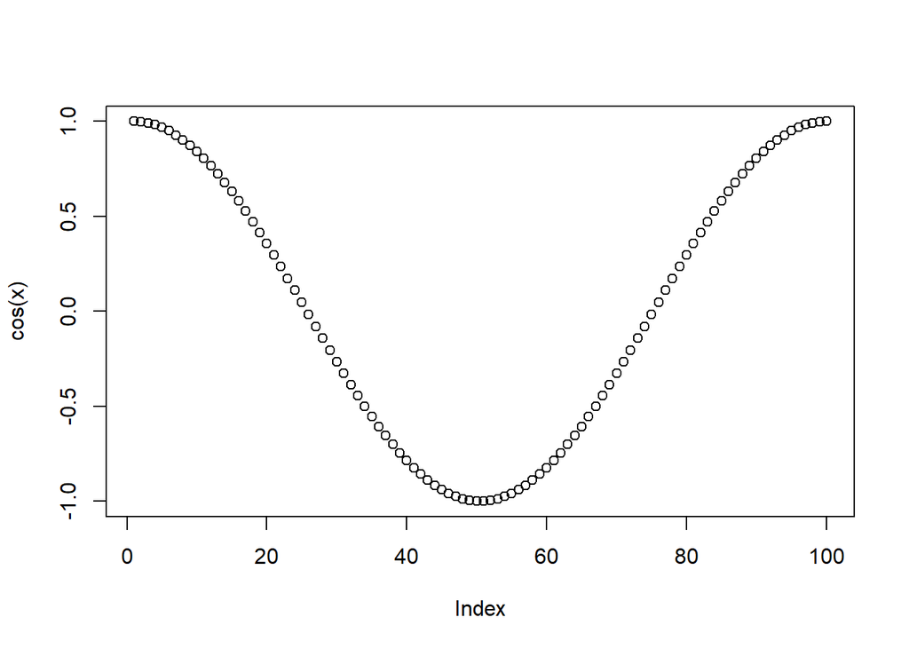

```r
x<-seq(0,2*pi,length=100)
plot(cos(x))
```

En el eje x se muestra los índices de los valores de cos(x) de 1 a 100 y en el eje y se muestra los valores de cos(x). No se indican los valores reales de x el cual es el intervalo [0, 2π], este no se ve.

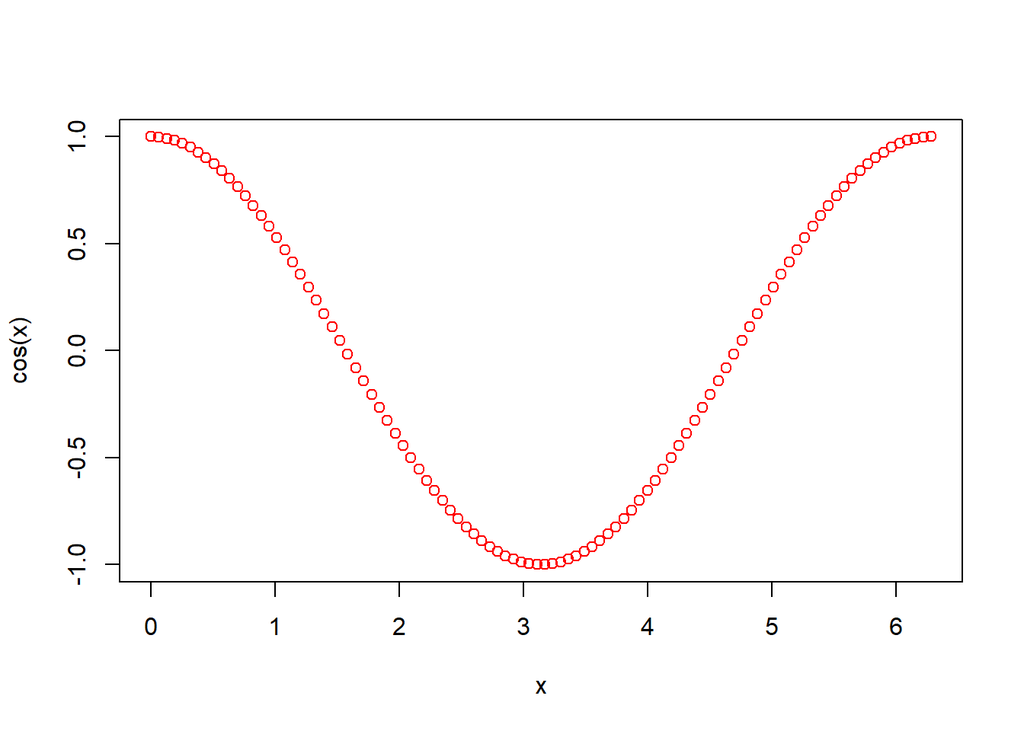

```r
plot(x,cos(x),col="red")
```

### Ejercicio 8

- Para tabla de Datos que viene en el archivo DJTable.csv el cual contiene los valores de las acciones de las principales empresas de Estados Unidos en el a˜no 2010, usando el comando plot de R, grafique (en un mismo gráfico) las series de valores de las acciones de las empresas CSCO (Cisco), IBM, INTC (Intel) y MSFT (Microsoft).

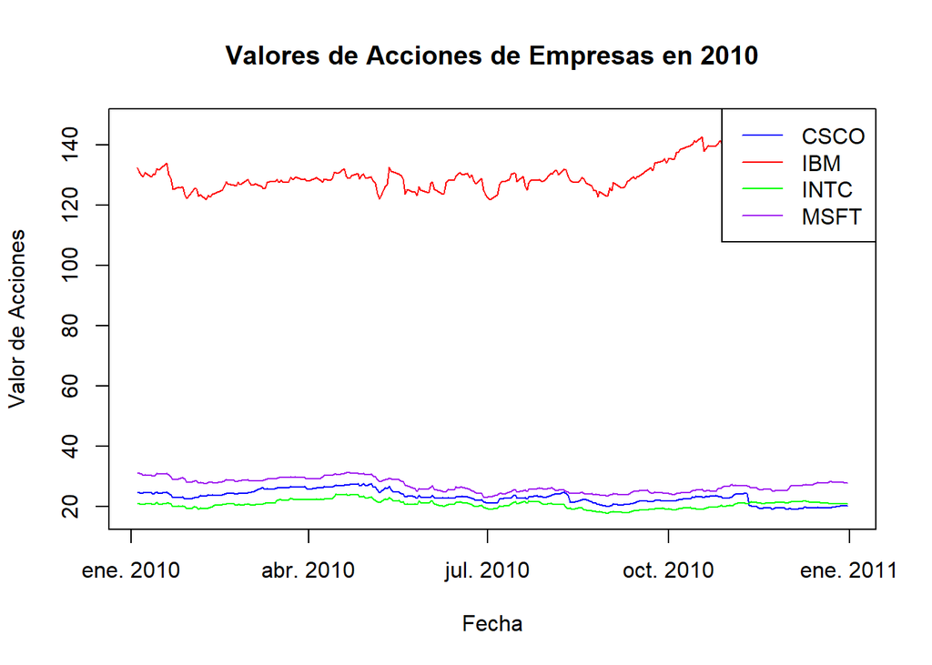

```r
datos<-read.csv("./DatosTarea1/DJTable.csv",sep = ";",dec='.',header=T, stringsAsFactors = T)
datos$X <- as.Date(as.character(datos$X), format = "%d/%m/%Y")

#Graficar las acciones
plot(datos$X, datos$CSCO, type = "l", col = "blue", ylim = range(datos[, c("CSCO", "IBM", "INTC", "MSFT")]),
     xlab = "Fecha", ylab = "Valor de Acciones", main = "Valores de Acciones de Empresas en 2010")
lines(datos$X, datos$IBM, col = "red")
lines(datos$X, datos$INTC, col = "green")
lines(datos$X, datos$MSFT, col = "purple")

#leyenda
legend("topright", legend = c("CSCO", "IBM", "INTC", "MSFT"), col = c("blue", "red", "green", "purple"), lty = 1)
```

### Ejercicio 9

- Repita el ejercicio anterior usando funciones del paquete ggplot2

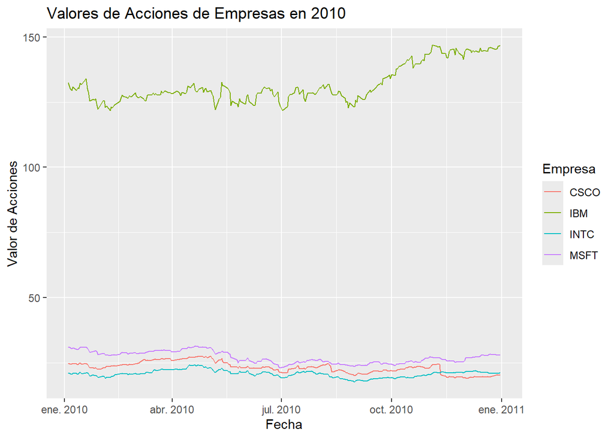

```r
library(ggplot2)

datos <- read.csv("./DatosTarea1/DJTable.csv", sep = ";", dec='.', header=T, stringsAsFactors = T)
datos$X <- as.Date(as.character(datos$X), format = "%d/%m/%Y")

ggplot(datos, aes(x = X)) +
  geom_line(aes(y = CSCO, color = "CSCO")) +
  geom_line(aes(y = IBM, color = "IBM")) +
  geom_line(aes(y = INTC, color = "INTC")) +
  geom_line(aes(y = MSFT, color = "MSFT")) +
  labs(x = "Fecha", y = "Valor de Acciones",
       title = "Valores de Acciones de Empresas en 2010") +
  scale_color_discrete(name = "Empresa")
```

### Ejercicio 10

```r
Datos <- read.table("./DatosTarea1/EjemploAlgoritmosRecomendacion.csv",header=TRUE, sep = ";", dec=',',row.names=1)
```

- Calcule la dimensión de la Tabla de Datos.

```r
dim(Datos)
```

```
## [1] 100   9
```

- Despliegue las primeras 2 columnas de la tabla de datos.

```r
head(Datos[,1:2])
```

```
##         VelocidadEntrega Precio
## Adam                2.05   0.30
## Anna                0.90   1.50
## Bernard             1.70   2.60
## Edward              1.35   0.50
## Emilia              3.00   0.45
## Fabian              0.95   1.65
```

- Ejecute un “summary” y un “str” de los datos.

```r
summary(Datos)
```

```
##  VelocidadEntrega     Precio        Durabilidad    ImagenProducto
##  Min.   :0.000    Min.   :0.1000   Min.   :2.500   Min.   :1.250
##  1st Qu.:1.250    1st Qu.:0.7375   1st Qu.:3.350   1st Qu.:2.288
##  Median :1.700    Median :1.0750   Median :4.025   Median :2.500
##  Mean   :1.758    Mean   :1.1820   Mean   :3.947   Mean   :2.624
##  3rd Qu.:2.300    3rd Qu.:1.6125   3rd Qu.:4.550   3rd Qu.:3.000
##  Max.   :3.050    Max.   :2.7000   Max.   :5.000   Max.   :4.100
##  ValorEducativo  ServicioRetorno TamanoPaquete   Calidad.Producto
##  Min.   :0.700   Min.   :1.100   Min.   :1.850   Min.   :1.600
##  1st Qu.:2.400   1st Qu.:2.200   1st Qu.:2.900   1st Qu.:2.050
##  Median :3.000   Median :2.600   Median :3.575   Median :2.425
##  Mean   :2.916   Mean   :2.665   Mean   :3.486   Mean   :2.385
##  3rd Qu.:3.425   3rd Qu.:3.000   3rd Qu.:4.162   3rd Qu.:2.700
##  Max.   :4.600   Max.   :4.600   Max.   :5.000   Max.   :3.400
##  NumeroEstrellas
##  Min.   :1.000
##  1st Qu.:2.400
##  Median :3.150
##  Mean   :3.110
##  3rd Qu.:3.825
##  Max.   :5.000
```

```r
str(Datos)
```

```
## 'data.frame':    100 obs. of  9 variables:
##  $ VelocidadEntrega: num  2.05 0.9 1.7 1.35 3 0.95 2.3 0.65 2.75 2 ...
##  $ Precio          : num  0.3 1.5 2.6 0.5 0.45 1.65 1.2 2.1 0.8 1.75 ...
##  $ Durabilidad     : num  3.45 3.15 2.85 3.55 4.8 3.95 4.75 3.1 4.7 3.25 ...
##  $ ImagenProducto  : num  2.35 3.3 3 2.95 3.9 2.4 3.3 2.55 2.35 3 ...
##  $ ValorEducativo  : num  2.4 2.5 4.3 1.8 3.4 2.6 3.5 2.8 3.5 3.7 ...
##  $ ServicioRetorno : num  2.3 4 2.7 2.3 4.6 1.9 4.5 2.2 3 3.2 ...
##  $ TamanoPaquete   : num  2.6 4.2 4.1 3.9 2.25 4.85 3.8 3.45 3.8 4.35 ...
##  $ Calidad.Producto: num  2.1 2.15 2.6 1.95 3.4 2.2 2.9 2.15 2.7 2.7 ...
##  $ NumeroEstrellas : num  1.7 2.8 3.3 1.7 4.3 3 3.1 2.9 4.8 3.9 ...
```

- Calcule la Media y la Desviación Estándar para todas las variables cualesquiera.

```r
media <- colMeans(Datos)
desviacion.estandar <- apply(Datos, 2, sd)

print(media)
```

```
## VelocidadEntrega           Precio      Durabilidad   ImagenProducto
##           1.7575           1.1820           3.9470           2.6240
##   ValorEducativo  ServicioRetorno    TamanoPaquete Calidad.Producto
##           2.9160           2.6650           3.4855           2.3855
##  NumeroEstrellas
##           3.1100
```

```r
print(desviacion.estandar)
```

```
## VelocidadEntrega           Precio      Durabilidad   ImagenProducto
##        0.6603632        0.5978294        0.6932510        0.5657069
##   ValorEducativo  ServicioRetorno    TamanoPaquete Calidad.Producto
##        0.7512575        0.7708548        0.7926205        0.4277788
##  NumeroEstrellas
##        0.8988770
```

- Ahora repita los ´ıtems anteriores pero leyendo el archivo como sigue:

```r
Datos <- read.table("./DatosTarea1/EjemploAlgoritmosRecomendacion.csv", header=TRUE, sep=";",dec='.',row.names=1)
```

- Calcule la dimensión de la Tabla de Datos.

```r
dim(Datos)
```

```
## [1] 100   9
```

- Despliegue las primeras 2 columnas de la tabla de datos.

```r
head(Datos[,1:2])
```

```
##         VelocidadEntrega Precio
## Adam                2,05    0,3
## Anna                 0,9    1,5
## Bernard              1,7    2,6
## Edward              1,35    0,5
## Emilia                 3   0,45
## Fabian              0,95   1,65
```

- Ejecute un “summary” y un “str” de los datos.

```r
summary(Datos)
```

```
##  VelocidadEntrega      Precio          Durabilidad        ImagenProducto
##  Length:100         Length:100         Length:100         Length:100
##  Class :character   Class :character   Class :character   Class :character
##  Mode  :character   Mode  :character   Mode  :character   Mode  :character
##  ValorEducativo     ServicioRetorno    TamanoPaquete      Calidad.Producto
##  Length:100         Length:100         Length:100         Length:100
##  Class :character   Class :character   Class :character   Class :character
##  Mode  :character   Mode  :character   Mode  :character   Mode  :character
##  NumeroEstrellas
##  Length:100
##  Class :character
##  Mode  :character
```

```r
str(Datos)
```

```
## 'data.frame':    100 obs. of  9 variables:
##  $ VelocidadEntrega: chr  "2,05" "0,9" "1,7" "1,35" ...
##  $ Precio          : chr  "0,3" "1,5" "2,6" "0,5" ...
##  $ Durabilidad     : chr  "3,45" "3,15" "2,85" "3,55" ...
##  $ ImagenProducto  : chr  "2,35" "3,3" "3" "2,95" ...
##  $ ValorEducativo  : chr  "2,4" "2,5" "4,3" "1,8" ...
##  $ ServicioRetorno : chr  "2,3" "4" "2,7" "2,3" ...
##  $ TamanoPaquete   : chr  "2,6" "4,2" "4,1" "3,9" ...
##  $ Calidad.Producto: chr  "2,1" "2,15" "2,6" "1,95" ...
##  $ NumeroEstrellas : chr  "1,7" "2,8" "3,3" "1,7" ...
```

- Calcule la Media y la Desviación Estándar para todas las variables cualesquiera.

```r
#media <- colMeans(Datos, na.rm = TRUE)
#desviacion.estandar <- apply(Datos, 2, sd, na.rm = TRUE)

#print(media)
#print(desviacion.estandar)
```

- ¿Porqué todo da mal o genera error?: Esto se debe por el separador decimal, R está tomando los decimales como datos no numéricos, por lo cual no se pueden hacer los cálculos correctamente.

### Ejercicio 11

```r
Datos <- read.table("./DatosTarea1/EjemploAlgoritmosRecomendacion.csv",header=TRUE, sep = ";", dec=',',row.names=1)
```

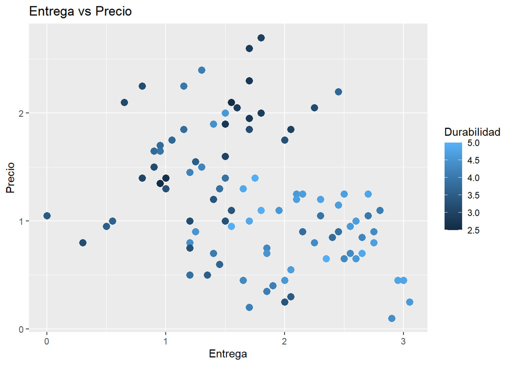

```r
qplot(x=VelocidadEntrega, y=Precio, data=Datos,
      main="Entrega vs Precio",
      xlab="Entrega",
      ylab="Precio",
      color=Durabilidad,
      size=I(3),
      shape=I(16))
```

- Grafique usando comando scatterplot3d en 3 dimensiones las variables Entrega, Precio y Durabilidad.

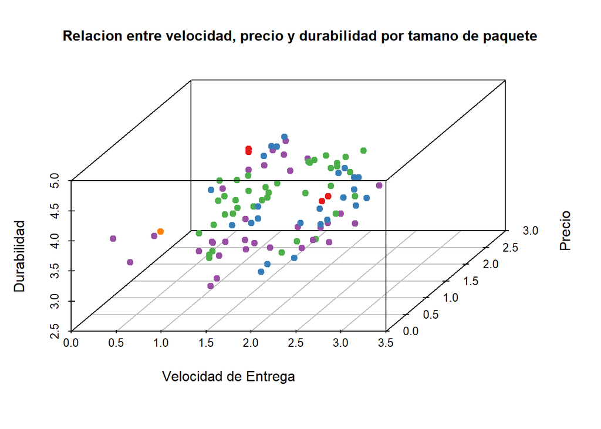

```r
library(scatterplot3d)
library(RColorBrewer)


paleta.colores <- brewer.pal(9, "Set1")

scatterplot3d(x = Datos$VelocidadEntrega,
              y = Datos$Precio,
              z = Datos$Durabilidad,
              xlab = "Velocidad de Entrega",
              ylab = "Precio",
              zlab = "Durabilidad",
              pch = 19,
              color = paleta.colores[Datos$TamanoPaquete],
              angle = 50,
              main = "Relacion entre velocidad, precio y durabilidad por tamano de paquete",
              cex.main = 1,
              oma = c(7, 3, 7, 3))
```

- Usando el comando cor calcule la matriz de correlaciones de la tabla EjemploAlgoritmos Recomendacion.csv y grafique esta matriz de 4 formas diferentes.

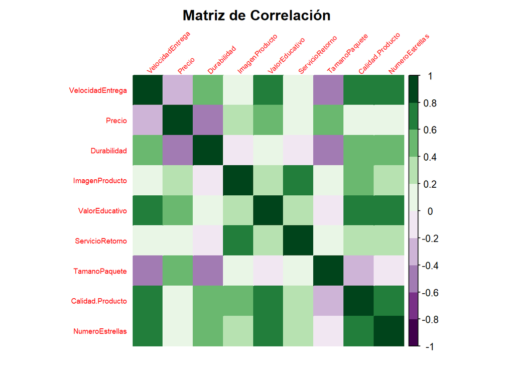

```r
library(corrplot)
correlaciones <- cor(Datos[, sapply(Datos, is.numeric)])  # Solo columnas numéricas

# Gráfico 1:
corrplot(correlaciones, method = "color", title = "Matriz de Correlación",
         tl.cex = 0.6,
         tl.srt = 45,  # Rotar etiquetas
         mar = c(1, 1, 2, 1),
        col = COL2("PRGn", 10))
```

[figure not shown]

```r
#Grafico 2:
corrplot(correlaciones, method = "shade", order ='AOE', diag = FALSE, col = COL2("RdBu", 10))
```

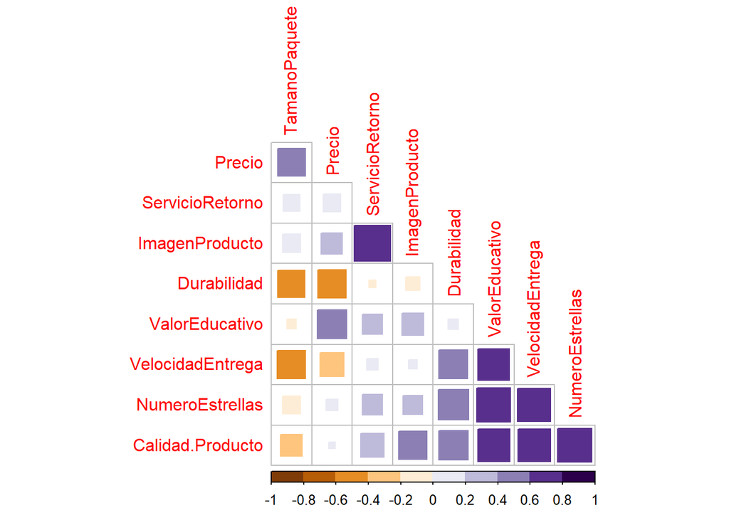

```r
#Grafico 3
corrplot(correlaciones, method= "square", order= "FPC", type="lower", diag = FALSE,
         col = COL2("PuOr", 10))
```

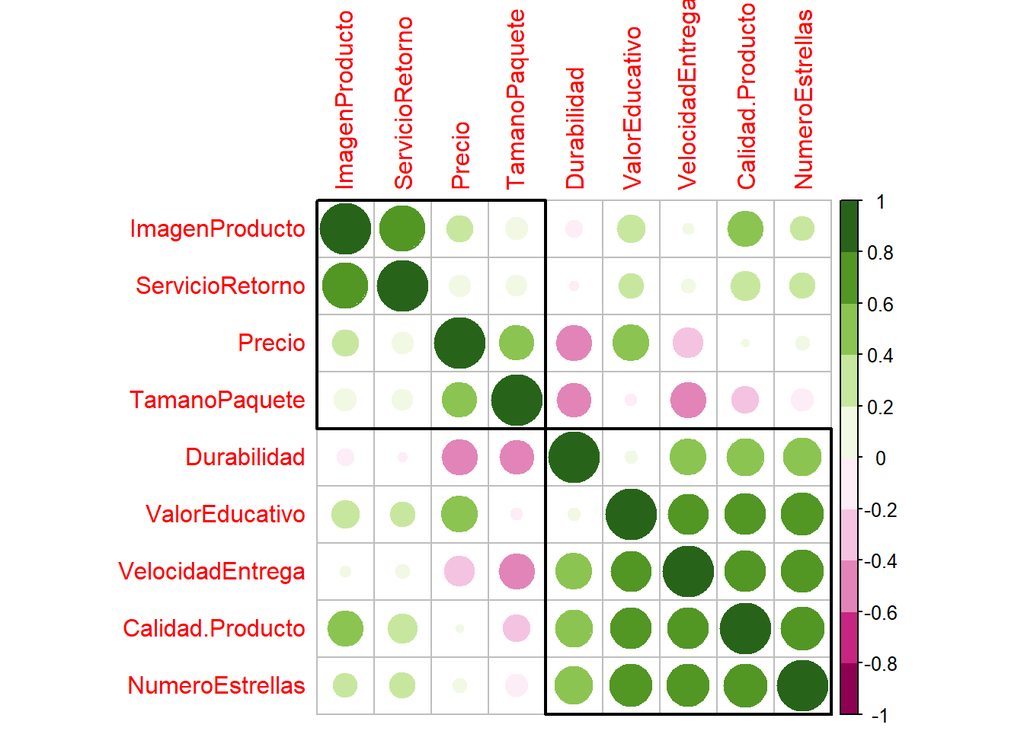

```r
#Grafico 4
corrplot(correlaciones, order = "hclust", addrect = 2, col = COL2("PiYG", 10))
```

- Usando el comando Boxplot encuentre los datos atípicos de la tabla de datos Ejemplo AlgoritmosRecomendacion.csv.

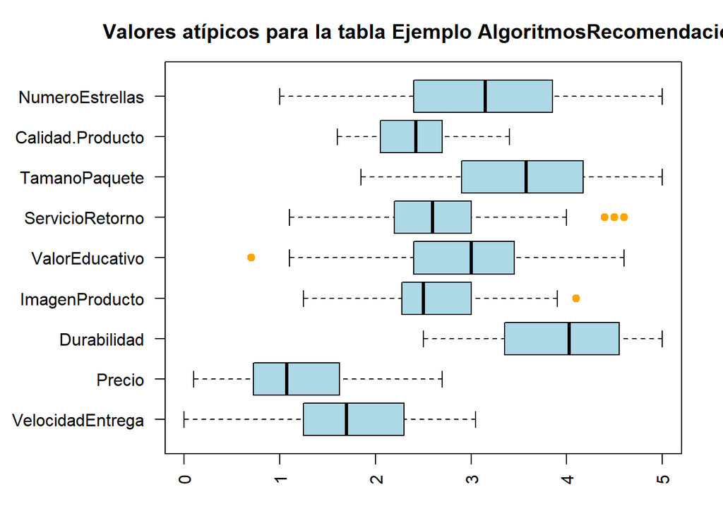

```r
par(mar = c(3,8,3,2))
boxplot(Datos[, sapply(Datos, is.numeric)],
        main = "Valores atípicos para la tabla Ejemplo AlgoritmosRecomendacion",
        col = "lightblue",
        outcol = "orange",
        horizontal = T,
        outpch = 19,

        las = 2)
```

### Ejercicio 12

- Cargue la tabla de datos que está en el archivo SAheartv.csv

```r
datos2 <- read.table("./DatosTarea1/SAheart.csv", sep = ";", dec='.', header=T, stringsAsFactors = T)
```

- Calcule la dimensión de la Tabla de Datos.

```r
dim(datos2)
```

```
## [1] 462  10
```

- Despliegue las primeras 3 columnas de la tabla de datos.

```r
head(datos2[, 1:3])
```

```
##   sbp tobacco  ldl
## 1 160   12.00 5.73
## 2 144    0.01 4.41
## 3 118    0.08 3.48
## 4 170    7.50 6.41
## 5 134   13.60 3.50
## 6 132    6.20 6.47
```

- Ejecute un summary y un str de los datos.

```r
summary(datos2)
```

```
##       sbp           tobacco             ldl           adiposity
##  Min.   :101.0   Min.   : 0.0000   Min.   : 0.980   Min.   : 6.74
##  1st Qu.:124.0   1st Qu.: 0.0525   1st Qu.: 3.283   1st Qu.:19.77
##  Median :134.0   Median : 2.0000   Median : 4.340   Median :26.11
##  Mean   :138.3   Mean   : 3.6356   Mean   : 4.740   Mean   :25.41
##  3rd Qu.:148.0   3rd Qu.: 5.5000   3rd Qu.: 5.790   3rd Qu.:31.23
##  Max.   :218.0   Max.   :31.2000   Max.   :15.330   Max.   :42.49
##     famhist        typea         obesity         alcohol            age
##  Absent :270   Min.   :13.0   Min.   :14.70   Min.   :  0.00   Min.   :15.00
##  Present:192   1st Qu.:47.0   1st Qu.:22.98   1st Qu.:  0.51   1st Qu.:31.00
##                Median :53.0   Median :25.80   Median :  7.51   Median :45.00
##                Mean   :53.1   Mean   :26.04   Mean   : 17.04   Mean   :42.82
##                3rd Qu.:60.0   3rd Qu.:28.50   3rd Qu.: 23.89   3rd Qu.:55.00
##                Max.   :78.0   Max.   :46.58   Max.   :147.19   Max.   :64.00
##  chd
##  No:302
##  Si:160
##
##
##
##
```

```r
str(datos2)
```

```
## 'data.frame':    462 obs. of  10 variables:
##  $ sbp      : int  160 144 118 170 134 132 142 114 114 132 ...
##  $ tobacco  : num  12 0.01 0.08 7.5 13.6 6.2 4.05 4.08 0 0 ...
##  $ ldl      : num  5.73 4.41 3.48 6.41 3.5 6.47 3.38 4.59 3.83 5.8 ...
##  $ adiposity: num  23.1 28.6 32.3 38 27.8 ...
##  $ famhist  : Factor w/ 2 levels "Absent","Present": 2 1 2 2 2 2 1 2 2 2 ...
##  $ typea    : int  49 55 52 51 60 62 59 62 49 69 ...
##  $ obesity  : num  25.3 28.9 29.1 32 26 ...
##  $ alcohol  : num  97.2 2.06 3.81 24.26 57.34 ...
##  $ age      : int  52 63 46 58 49 45 38 58 29 53 ...
##  $ chd      : Factor w/ 2 levels "No","Si": 2 2 1 2 2 1 1 2 1 2 ...
```

- Usando el comando cor de R calcule la correlación entre las variables tobacco y alcohol.

```r
cor(x= datos2$tobacco, y= datos2$alcohol)
```

```
## [1] 0.2008134
```

- Calcule la suma de las columnas con variables cuantitativas (numéricas).

```r
cuantitativas <-datos2[, sapply(datos2, is.numeric)]
suma <- colSums(cuantitativas, na.rm = TRUE)
print(suma)
```

```
##       sbp   tobacco       ldl adiposity     typea   obesity   alcohol       age
##  63907.00   1679.67   2190.03  11737.91  24534.00  12032.38   7874.51  19781.00
```

- Calcule para todas las variables cuantitativas presentes en el archivo SAheart.csv: El mínimo, el máximo, la media, la mediana y para la variables chd determine la cantidad de Si y de No.

```r
cuantitativas <-datos2[, sapply(datos2, is.numeric)]
minimos <- apply(cuantitativas, 2, min, na.rm = TRUE)
maximos <- apply(cuantitativas, 2, max, na.rm = TRUE)
medias <- colMeans(cuantitativas, na.rm = TRUE)
medianas <- apply(cuantitativas, 2, median, na.rm = TRUE)

minimos
```

```
##       sbp   tobacco       ldl adiposity     typea   obesity   alcohol       age
##    101.00      0.00      0.98      6.74     13.00     14.70      0.00     15.00
```

```r
maximos
```

```
##       sbp   tobacco       ldl adiposity     typea   obesity   alcohol       age
##    218.00     31.20     15.33     42.49     78.00     46.58    147.19     64.00
```

```r
medias
```

```
##        sbp    tobacco        ldl  adiposity      typea    obesity    alcohol
## 138.326840   3.635649   4.740325  25.406732  53.103896  26.044113  17.044394
##        age
##  42.816017
```

```r
medianas
```

```
##       sbp   tobacco       ldl adiposity     typea   obesity   alcohol       age
##   134.000     2.000     4.340    26.115    53.000    25.805     7.510    45.000
```

```r
contar.chd = table(datos2$chd)
contar.chd
```

```
##
##  No  Si
## 302 160
```

### Ejercicio 13

- Función que genera 200 números al azar entre 1 y 500 y luego calcula cuántos están entre el 50 y 450, ambos inclusive.

```r
rango.numeros <- function() {

  num.aleatorios <- sample(1:500, 200, replace = TRUE)
  rango.50.450 <- sum(num.aleatorios >= 50 & num.aleatorios <= 450)

  return(rango.50.450)
}
resultado <- rango.numeros()

# Mostrar el resultado
print(resultado)
```

```
## [1] 155
```

### Ejercicio 14

- Función que calcula el costo de una llamada telefónica que ha durado t minutos sabiendo que si t < 1 el costo es de 0,4 dólares, mientras que para duraciones superiores el costo es de 0,4 + (t − 1)/4 dólares, la función debe recibir el valor de t.

```r
calcular.costo <- function(t){
  costo <- 0
  if(t < 1){
    costo <- 0.4
    return(costo)
  }
  else{
    costo <- (0.4+(t-1)/4)
    return(costo)
  }

}
calcular.costo(2)
```

```
## [1] 0.65
```

### Ejercicio 15

- Función que recibe una matriz cuadrada A de tamaño n × n y calcula su traza, es decir, la suma de los elementos de la diagonal.

```r
traza.matriz <- function(A) {
  if (!is.matrix(A) || nrow(A) != ncol(A)) {
    return("Debe ser una matriz cuadrada.")
  }
  traza <- sum(diag(A))
  return(traza)
}


matriz <- matrix(c(9, 3, 4,
                   1, 3, -1,
                   4, 12, -2),
                 nrow = 3, byrow = TRUE)

resultado <- traza.matriz(matriz)
print(resultado)
```

```
## [1] 10
```

### Ejercicio 16

- Función que genere los n primeros términos de la serie de Fibonacci.

```r
generar.fibonacci <- function(n) {
  fibonacci <- numeric(n)

  for (i in 1:n) {
    if (i == 1) {
      fibonacci[i] <- 0
    } else if (i == 2) {
      fibonacci[i] <- 1
    } else {
      fibonacci[i] <- fibonacci[i - 1] + fibonacci[i - 2]
    }
  }

  return(fibonacci)
}

n <- 10
resultado <- generar.fibonacci(n)
print(resultado)
```

```
##  [1]  0  1  1  2  3  5  8 13 21 34
```

### Ejercicio 17

- Función que retorne cuál es el mayor número entero cuyo cuadrado no excede de x donde x es un número real que se recibe como parámetro, utilizando while.

```r
mayor.cuadrado <- function(x) {
  if (!is.numeric(x)) {
    return("Debe ser un número real.")
  }

  mayor.entero <- 0
  cuadrado <- 0

  while (cuadrado <= x) {
    mayor.entero <- mayor.entero + 1
    cuadrado <- mayor.entero^2
  }

  return(mayor.entero - 1)
}

resultado <- mayor.cuadrado(20)
print(resultado)
```

```
## [1] 4
```

### Ejercicio 18

- Crear un Data Frame con diez alumnos con su edad, año de nacimiento y número de teléfono. Deberá aparecer el nombre de la columna (edad, año de nacimiento, teléfono) y el nombre de la fila, que ser´a el nombre del alumno al que corresponden los datos.

```r
alumnos <- data.frame(
  edad = c(20, 21, 19, 22, 20, 21, 23, 19, 22, 20),
  anio_nacimiento = c(2003, 2002, 2004, 2001, 2003, 2002, 2000, 2004, 2001, 2003),
  telefono = c("8888-8888", "8988-8801", "8834-3333",
               "8678-8008", "8123-8888", "8843-8855",
               "8823-7898", "8888-8765", "8888-8356", "8999-9838")
)

rownames(alumnos) <- c("Aslie", "Ana", "Dania", "Gladys", "Andrés",
                       "Juan", "Pablo", "María", "Paul", "Lucy")

print(alumnos)
```

```
##        edad anio_nacimiento  telefono
## Aslie    20            2003 8888-8888
## Ana      21            2002 8988-8801
## Dania    19            2004 8834-3333
## Gladys   22            2001 8678-8008
## Andrés   20            2003 8123-8888
## Juan     21            2002 8843-8855
## Pablo    23            2000 8823-7898
## María    19            2004 8888-8765
## Paul     22            2001 8888-8356
## Lucy     20            2003 8999-9838
```

### Ejercicio 19

- Función R que recibe un DataFrame que retorna la cantidad de entradas de este DataFrame que son divisibles entre 3.

```r
divisibles.por.tres <- function(df) {
  valores <- as.vector(as.matrix(df))
  cantidad.divisibles <- sum(valores %% 3 == 0)

  return(cantidad.divisibles)
}

# Ejemplo de uso
# Crear un Data Frame de ejemplo
df.prueba <- data.frame(
  col1 = c(1, 2, 3, 4, 5),
  col2 = c(6, 7, 8, 9, 10),
  col3 = c(11, 12, 13, 14, 15)
)

resultado <- divisibles.por.tres(df.prueba)
print(resultado)
```

```
## [1] 5
```

### Ejercicio 20

- Función R que recibe un DataFrame y dos números de columna y que retorna en una lista el nombre de las variables correspondientes a las columnas, la covarianza y la correlación entre esas dos variables.

```r
covarianza.correlacion <- function(df, col1, col2) {
  if (col1 > ncol(df) || col2 > ncol(df) || col1 < 1 || col2 < 1) {
    return("Las columnas no son válidas.")
  }

  nom.var1 <- colnames(df)[col1]
  nom.var2 <- colnames(df)[col2]

  covarianza <- cov(df[[col1]], df[[col2]])
  correlacion <- cor(df[[col1]], df[[col2]])

  resultados <- list(
    var1 = nom.var1,
    var2 = nom.var2,
    covarianza = covarianza,
    correlacion = correlacion
  )

  return(resultados)
}

df.prueba2 <- data.frame(
  altura = c(1.65, 1.70, 1.80, 1.75, 1.60),
  peso = c(55, 60, 75, 70, 50),
  edad = c(22, 23, 24, 21, 20)
)

resultado <- covarianza.correlacion(df.prueba2, 1, 2)
print(resultado)
```

```
## $var1
## [1] "altura"
##
## $var2
## [1] "peso"
##
## $covarianza
## [1] 0.8125
##
## $correlacion
## [1] 0.9912407
```

### Ejercicio 21

- Importe directamente desde Excel en R el archivo EjemploAlgoritmosRecomendación.xlsx el cual contiene los promedios de evaluación de 100 personas que adquirieron los mismos productos o muy similares en la tienda AMAZON. Luego ejecute un str(…) y un summary(…) con esta tabla de datos

```r
library(readxl)
datos_excel <- read_excel("./DatosTarea1/EjemploAlgoritmosRecomendacion.xlsx")
str(datos_excel)
```

```
## tibble [100 × 10] (S3: tbl_df/tbl/data.frame)
##  $ ...1             : chr [1:100] "Adam" "Anna" "Bernard" "Edward" ...
##  $ Velocidad Entrega: num [1:100] 2.05 0.9 1.7 1.35 3 0.95 2.3 0.65 2.75 2 ...
##  $ Precio           : num [1:100] 0.3 1.5 2.6 0.5 0.45 1.65 1.2 2.1 0.8 1.75 ...
##  $ Durabilidad      : num [1:100] 3.45 3.15 2.85 3.55 4.8 3.95 4.75 3.1 4.7 3.25 ...
##  $ Imagen Producto  : num [1:100] 2.35 3.3 3 2.95 3.9 2.4 3.3 2.55 2.35 3 ...
##  $ Valor Educativo  : num [1:100] 2.4 2.5 4.3 1.8 3.4 2.6 3.5 2.8 3.5 3.7 ...
##  $ Servicio Retorno : num [1:100] 2.3 4 2.7 2.3 4.6 1.9 4.5 2.2 3 3.2 ...
##  $ Tamano Paquete   : num [1:100] 2.6 4.2 4.1 3.9 2.25 4.85 3.8 3.45 3.8 4.35 ...
##  $ Calidad Producto : num [1:100] 2.1 2.15 2.6 1.95 3.4 2.2 2.9 2.15 2.7 2.7 ...
##  $ Numero Estrellas : num [1:100] 1.7 2.8 3.3 1.7 4.3 3 3.1 2.9 4.8 3.9 ...
```

```r
summary(datos_excel)
```

```
##      ...1           Velocidad Entrega     Precio        Durabilidad
##  Length:100         Min.   :0.000     Min.   :0.1000   Min.   :2.500
##  Class :character   1st Qu.:1.250     1st Qu.:0.7375   1st Qu.:3.350
##  Mode  :character   Median :1.700     Median :1.0750   Median :4.025
##                     Mean   :1.758     Mean   :1.1820   Mean   :3.947
##                     3rd Qu.:2.300     3rd Qu.:1.6125   3rd Qu.:4.550
##                     Max.   :3.050     Max.   :2.7000   Max.   :5.000
##  Imagen Producto Valor Educativo Servicio Retorno Tamano Paquete
##  Min.   :1.250   Min.   :0.700   Min.   :1.100    Min.   :1.850
##  1st Qu.:2.288   1st Qu.:2.400   1st Qu.:2.200    1st Qu.:2.900
##  Median :2.500   Median :3.000   Median :2.600    Median :3.575
##  Mean   :2.624   Mean   :2.916   Mean   :2.665    Mean   :3.486
##  3rd Qu.:3.000   3rd Qu.:3.425   3rd Qu.:3.000    3rd Qu.:4.162
##  Max.   :4.100   Max.   :4.600   Max.   :4.600    Max.   :5.000
##  Calidad Producto Numero Estrellas
##  Min.   :1.600    Min.   :1.000
##  1st Qu.:2.050    1st Qu.:2.400
##  Median :2.425    Median :3.150
##  Mean   :2.385    Mean   :3.110
##  3rd Qu.:2.700    3rd Qu.:3.825
##  Max.   :3.400    Max.   :5.000
```

### Ejercicio 22

- Función recursiva

```r
U <- function(n) {
  if (n == 0) {
    return(5)
  } else if (n == 1) {
    return(-5)
  } else if (n == 2) {
    return(2)
  } else {
    return(4 * U(n - 1) - 15 * U(n - 2) + U(n - 3))
  }
}


cat(U(0),"\n")
```

```
## 5
```

```r
cat(U(1),"\n")
```

```
## -5
```

```r
cat(U(2),"\n")
```

```
## 2
```

```r
cat(U(3),"\n")
```

```
## 88
```

### Ejercicio 23

- Función f(x) = x^n de forma recursiva.

```r
potencia <- function(x, n) {
  if (n == 0) {
    return(1)
  } else {
    return(x * potencia(x, n - 1))
  }
}

potencia(2, 4)
```

```
## [1] 16
```

### Ejercicio 24

- El archivo bosques energia.csv el cual contiene el resultado de dos estudios, uno en el que se mide la superficie boscosa en proporción al terreno total de cada país y el otro corresponde al consumo de energía renovable en proporción al consumo de energía total. Estos estudios se hicieron en varios países y en varios años distintos. Con estos datos realize lo siguiente:
- 1. Convierta los datos a datos tidy.

```r
library(tidyr)

datos <- read.csv("./DatosTarea1/bosques_energia.csv")

head(datos)
```

```
##          Pais Codigo.Pais
## 1       Aruba         ABW
## 2       Aruba         ABW
## 3 Afghanistan         AFG
## 4 Afghanistan         AFG
## 5      Angola         AGO
## 6      Angola         AGO
##                                                                   Indicador
## 1                        Superficie forestal (% de la superficie terrestre)
## 2 Consumo de energ\xeda renovable (% del consumo total de energ\xeda final)
## 3                        Superficie forestal (% de la superficie terrestre)
## 4 Consumo de energ\xeda renovable (% del consumo total de energ\xeda final)
## 5                        Superficie forestal (% de la superficie terrestre)
## 6 Consumo de energ\xeda renovable (% del consumo total de energ\xeda final)
##   X1960 X1961 X1962 X1963 X1964 X1965 X1966 X1967 X1968 X1969 X1970 X1971 X1972
```

[output cut: 48 more lines]

```r
datos.tidy<-pivot_longer(datos,
               cols = starts_with("X"),
               names_to = "Año",
               values_to = "Valor")

datos.tidy$Año <- as.numeric(sub("X", "", datos.tidy$Año))

head(datos.tidy)
```

```
## # A tibble: 6 × 5
##   Pais  Codigo.Pais Indicador                                          Año Valor
##   <chr> <chr>       <chr>                                            <dbl> <dbl>
## 1 Aruba ABW         Superficie forestal (% de la superficie terrest…  1960    NA
## 2 Aruba ABW         Superficie forestal (% de la superficie terrest…  1961    NA
## 3 Aruba ABW         Superficie forestal (% de la superficie terrest…  1962    NA
## 4 Aruba ABW         Superficie forestal (% de la superficie terrest…  1963    NA
## 5 Aruba ABW         Superficie forestal (% de la superficie terrest…  1964    NA
## 6 Aruba ABW         Superficie forestal (% de la superficie terrest…  1965    NA
```

- 2. Elimine las variables innecesarias y explique el motivo. Se elimina la variable codigo.pais porque hay una variable pais y no es necesario tener ambas.

```r
datos.tidy <- datos.tidy[, !colnames(datos.tidy) %in% "Codigo.Pais"]


head(datos.tidy)
```

```
## # A tibble: 6 × 4
##   Pais  Indicador                                            Año Valor
##   <chr> <chr>                                              <dbl> <dbl>
## 1 Aruba Superficie forestal (% de la superficie terrestre)  1960    NA
## 2 Aruba Superficie forestal (% de la superficie terrestre)  1961    NA
## 3 Aruba Superficie forestal (% de la superficie terrestre)  1962    NA
## 4 Aruba Superficie forestal (% de la superficie terrestre)  1963    NA
## 5 Aruba Superficie forestal (% de la superficie terrestre)  1964    NA
## 6 Aruba Superficie forestal (% de la superficie terrestre)  1965    NA
```

- 3. Con la ayuda del paquete dplyr, realice lo siguiente:
  - Con un gráfico muestre la evolución del consumo de energía renovable para los países Canada, Paraguay, Perú y China. Debe mostrar tanto el gráfico como la tabla de datos con la que se realizó el gráfico.

```r
datos.energia <- datos.tidy[datos.tidy$Indicador == "Consumo de energ\xeda renovable (% del consumo total de energ\xeda final)" &
                            datos.tidy$Pais %in% c("Canada", "Paraguay", "Peru", "China"), ]

datos.energia <- datos.energia[!is.na(datos.energia$Valor), ]

print(datos.energia)
```

```
## # A tibble: 104 × 4
##    Pais   Indicador                                                    Año Valor
##    <chr>  <chr>                                                      <dbl> <dbl>
##  1 Canada Consumo de energ�a renovable (% del consumo total de ener…  1990  22.0
##  2 Canada Consumo de energ�a renovable (% del consumo total de ener…  1991  22.2
##  3 Canada Consumo de energ�a renovable (% del consumo total de ener…  1992  21.9
##  4 Canada Consumo de energ�a renovable (% del consumo total de ener…  1993  21.8
##  5 Canada Consumo de energ�a renovable (% del consumo total de ener…  1994  21.7
##  6 Canada Consumo de energ�a renovable (% del consumo total de ener…  1995  21.9
##  7 Canada Consumo de energ�a renovable (% del consumo total de ener…  1996  21.6
##  8 Canada Consumo de energ�a renovable (% del consumo total de ener…  1997  21.3
##  9 Canada Consumo de energ�a renovable (% del consumo total de ener…  1998  21.5
## 10 Canada Consumo de energ�a renovable (% del consumo total de ener…  1999  21.7
## # ℹ 94 more rows
```

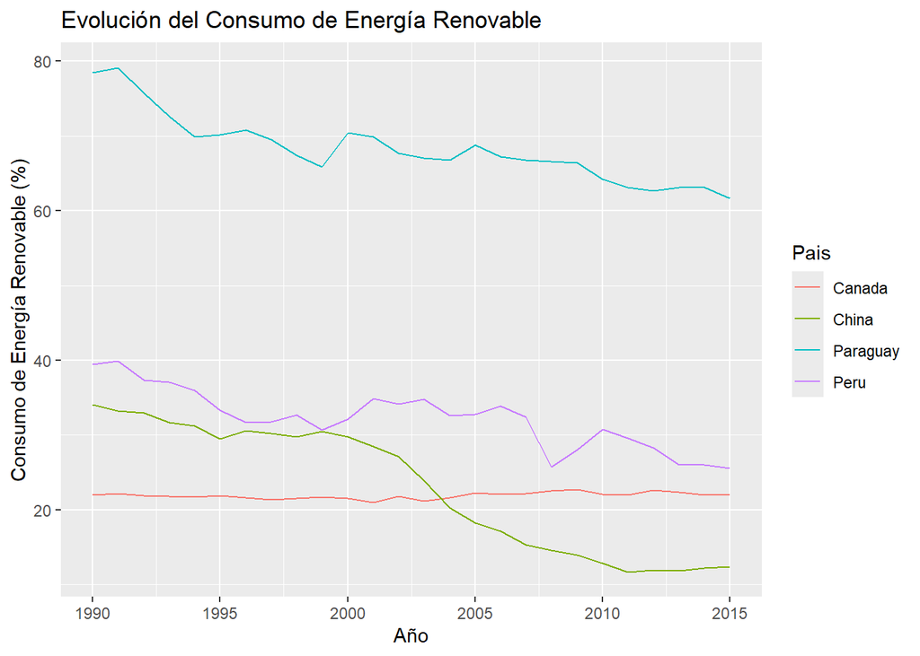

```r
ggplot(datos.energia, aes(x = Año, y = Valor, color = Pais)) +
  geom_line() +
  labs(x = "Año", y = "Consumo de Energía Renovable (%)", title = "Evolución del Consumo de Energía Renovable")
```

```r
library(dplyr)
```

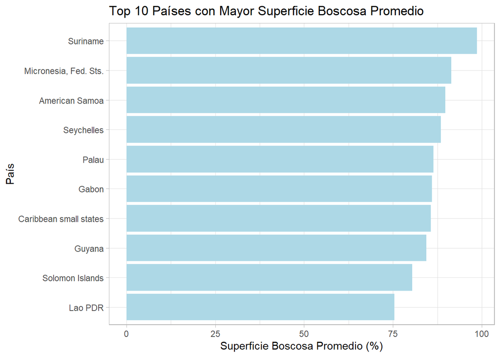

```r
datos.bosque <- summarize(
  group_by(
    filter(datos.tidy, Indicador == "Superficie forestal (% de la superficie terrestre)"),
    Pais
  ),
  Superficie.Promedio = mean(Valor, na.rm = TRUE)
)

datos.bosque <- datos.bosque[order(-datos.bosque$Superficie.Promedio), ]
datos.bosque <- head(datos.bosque, 10)


ggplot(datos.bosque, aes(x = reorder(Pais, Superficie.Promedio), y = Superficie.Promedio)) +
  geom_bar(stat = "identity", fill = "lightblue") +
  labs(x = "País", y = "Superficie Boscosa Promedio (%)", title = "Top 10 Países con Mayor Superficie Boscosa Promedio") +
  coord_flip() +
  guides(fill = "none") +  # Quitar la leyenda
  theme_light()
```

### Ejercicio 25

- El archivo DatosEducacion.csv contiene información de las escuales primarias de varios países durante los años 2013 a 2019. Las variables están por filas, los valores de dichas variables están en forma columna por año.
- 1. Convierta el dataset a uno tidy. Elimine las variables innecesarias y los valores con NA.

```r
library(dplyr)
library(tidyr)
library(readr)

datos <- read_csv("./DatosTarea1/DatosEducacion.csv")
head(datos)
```

```
## # A tibble: 6 × 5
##   indicador iso3                                   pais  fecha      valor
##       <dbl> <chr>                                  <chr> <chr>      <dbl>
## 1     57348 Cantidad de Estudiantes que repitieron TGO   Togo  2013253214
## 2     57349 Cantidad de Estudiantes que repitieron TGO   Togo  2014158276
## 3     57350 Cantidad de Estudiantes que repitieron TGO   Togo  2015132214
## 4     57351 Cantidad de Estudiantes que repitieron TGO   Togo  2016118488
## 5     57352 Cantidad de Estudiantes que repitieron TGO   Togo  2017117760
## 6     57353 Cantidad de Estudiantes que repitieron TGO   Togo  2018117099
```

```r
datos_tidy <- datos %>%
  filter(!is.na(valor)) %>%
  select(iso3, pais, fecha, valor)

head(datos_tidy)
```

```
## # A tibble: 6 × 4
##   iso3                                   pais  fecha      valor
##   <chr>                                  <chr> <chr>      <dbl>
## 1 Cantidad de Estudiantes que repitieron TGO   Togo  2013253214
## 2 Cantidad de Estudiantes que repitieron TGO   Togo  2014158276
## 3 Cantidad de Estudiantes que repitieron TGO   Togo  2015132214
## 4 Cantidad de Estudiantes que repitieron TGO   Togo  2016118488
## 5 Cantidad de Estudiantes que repitieron TGO   Togo  2017117760
## 6 Cantidad de Estudiantes que repitieron TGO   Togo  2018117099
```

- 2. Agrupe el dataset por país y promedie los resultados, no incluya la variable fecha. Además, cambie los nombres de las variables a unos más ‘cortos’.

```r
datos.promedio <- datos_tidy %>%
  group_by(pais) %>%
  summarise(
    Repitentes = mean(valor, na.rm = TRUE)
  ) %>%
  ungroup()


head(datos.promedio, 20)
```

```
## # A tibble: 20 × 2
##    pais    Repitentes
##    <chr>        <dbl>
##  1 ABW       5842908.
##  2 AFG    5510807313.
##  3 AGO    9410422768.
##  4 AIA         20167
##  5 ALB     355953718.
##  6 AND         97901.
##  7 ANT         20166
##  8 ARE     588336716.
##  9 ARG    3096036182.
## 10 ARM     314471954.
## 11 ASM         20166
## 12 ATG       5573423.
## 13 AUS    4435695738.
## 14 AUT     357426368.
## 15 AZE     295830907.
## 16 BDI    4643384817.
## 17 BEL     410998090.
## 18 BEN    4086960152.
## 19 BFA    3405470985.
## 20 BGD   59031506566.
```

[output not shown]